# Somalia population disagregation data analysis and visualization

```r
library(tidyverse) # meta package of all tidyverse packages
```

```r
# Read Excel file
df <- read_csv("somalia_population_disagregation.csv")
# View the data
df
```

| Region | District | Total population estimate | of whom IDPs | of whom non-displaced | Displaced Children | Displaced Men | Displaced Women | Displaced Elderly | Subtotal - displaced...10 | Non Displaced Children | Non Displaced Men | Non Displaced Women | Non Displaced Elderly | Subtotal - displaced...15 | Total Children | Total Men | Total Women | Total Elderly | Total |
| --- | --- | --- | --- | --- | --- | --- | --- | --- | --- | --- | --- | --- | --- | --- | --- | --- | --- | --- | --- |
| Middle Shabelle | Adan Yabaal | 85950 | 0 | 85950 | 0 | 0 | 0 | 0 | 0 | 53232 | 15076 | 14796 | 2847 | 85951 | 53232 | 15076 | 14796 | 2847 | 85951 |
| Lower Shabelle | Afgooye | 472223 | 66200 | 406023 | 38358 | 12219 | 11307 | 4316 | 66200 | 251463 | 71217 | 69894 | 13450 | 406024 | 289821 | 83436 | 81201 | 17766 | 472224 |
| Lower Juba | Afmadow | 233519 | 2600 | 230919 | 1507 | 480 | 444 | 170 | 2601 | 143016 | 40503 | 39751 | 7649 | 230919 | 144523 | 40983 | 40195 | 7819 | 233520 |
| Gedo | Baardheere | 172267 | 18400 | 153867 | 10662 | 3396 | 3143 | 1200 | 18401 | 95295 | 26988 | 26487 | 5097 | 153867 | 105957 | 30384 | 29630 | 6297 | 172268 |
| Lower Juba | Badhaadhe | 71363 | 2000 | 69363 | 1113 | 399 | 373 | 115 | 2000 | 40590 | 13752 | 13359 | 1662 | 69363 | 41703 | 14151 | 13732 | 1777 | 71363 |
| Bay | Baidoa | 620749 | 454200 | 166549 | 252758 | 90622 | 84617 | 26204 | 454201 | 97462 | 33020 | 32076 | 3991 | 166549 | 350220 | 123642 | 116693 | 30195 | 620750 |
| Awdal | Baki | 55939 | 2700 | 53239 | 1503 | 539 | 503 | 156 | 2701 | 31155 | 10555 | 10253 | 1276 | 53239 | 32658 | 11094 | 10756 | 1432 | 55940 |
| Middle Shabelle | Balcad | 334620 | 61500 | 273120 | 37728 | 10809 | 10911 | 2052 | 61500 | 173266 | 45703 | 48153 | 5998 | 273120 | 210994 | 56512 | 59064 | 8050 | 334620 |
| Banadir | Banadir | 2683312 | 904000 | 1779312 | 554567 | 158879 | 160387 | 30167 | 904000 | 1128787 | 297744 | 313705 | 39076 | 1779312 | 1683354 | 456623 | 474092 | 69243 | 2683312 |
| Bari | Bandarbayla | 42436 | 2000 | 40436 | 1227 | 352 | 355 | 67 | 2001 | 25652 | 6766 | 7129 | 888 | 40435 | 26879 | 7118 | 7484 | 955 | 42436 |

[output cut: 64 more lines]

```r
NA
```

```r
# Get dimensions of data frame
dim(df)
```

```
[1] 74 20
```

```r
# view default column names before we change
colnames(df)
```

```
 [1] "Region"                    "District"                  "Total population estimate" "of whom IDPs"
 [5] "of whom non-displaced"     "Displaced Children"        "Displaced Men"             "Displaced Women"
 [9] "Displaced Elderly"         "Subtotal - displaced...10" "Non Displaced Children"    "Non Displaced Men"
[13] "Non Displaced Women"       "Non Displaced Elderly"     "Subtotal - displaced...15" "Total Children"
[17] "Total Men"                 "Total Women"               "Total Elderly"             "Total"
```

```r
# calculate the sum of missing values in the dataframe
sum(is.na(df))
```

```
[1] 0
```

```r
# view rows with missing values
na_rows <- df[!complete.cases(df), ]

#view results
na_rows
```

| Region | District | Total population estimate | of whom IDPs | of whom non-displaced | Displaced Children | Displaced Men | Displaced Women | Displaced Elderly | Subtotal - displaced...10 | Non Displaced Children | Non Displaced Men | Non Displaced Women | Non Displaced Elderly | Subtotal - displaced...15 | Total Children | Total Men | Total Women | Total Elderly | Total |
| --- | --- | --- | --- | --- | --- | --- | --- | --- | --- | --- | --- | --- | --- | --- | --- | --- | --- | --- | --- |

```r
NA
```

```r
# view duplicated values in df
sum(duplicated(df))
```

```
[1] 0
```

as you see here there is no duplicate rows in our dataset. but, there is duplicate columns with different column names in our dataset. to see this we can use manual method to detect column duplicates.

before we detect and remove lets rename our columns for better reference.

```r
# change column names
colnames(df) <- c("Region", "District", "Total_population", "IDPs", "Non_displaced",
                   "IDPs_children", "IDPs_men", "IDPs_women", "IDPs_elderly", "Subtotal_IDPs",
                   "Non_disp_children", "Non_disp_men", "Non_disp_women", "Non_disp_elderly",
                   "Subtotal_non_displaced", "Total_children", "Total_men", "Total_women",
                   "Total_elderly", "Total")
```

```r
# view 6 duplicated columns
df[, c("Total_population", "Total", "IDPs", "Subtotal_IDPs", "Non_displaced", "Subtotal_non_displaced")]
```

| Total_population | Total | IDPs | Subtotal_IDPs | Non_displaced | Subtotal_non_displaced |
| --- | --- | --- | --- | --- | --- |
| 85950 | 85951 | 0 | 0 | 85950 | 85951 |
| 472223 | 472224 | 66200 | 66200 | 406023 | 406024 |
| 233519 | 233520 | 2600 | 2601 | 230919 | 230919 |
| 172267 | 172268 | 18400 | 18401 | 153867 | 153867 |
| 71363 | 71363 | 2000 | 2000 | 69363 | 69363 |
| 620749 | 620750 | 454200 | 454201 | 166549 | 166549 |
| 55939 | 55940 | 2700 | 2701 | 53239 | 53239 |
| 334620 | 334620 | 61500 | 61500 | 273120 | 273120 |
| 2683312 | 2683312 | 904000 | 904000 | 1779312 | 1779312 |
| 42436 | 42436 | 2000 | 2001 | 40436 | 40435 |

[output cut: 64 more lines]

```r
NA
```

```r
df <- subset(df, select = -c(Total, Subtotal_IDPs, Subtotal_non_displaced))
df
```

|  | Region | District | Total_population | IDPs | Non_displaced | IDPs_children | IDPs_men | IDPs_women | IDPs_elderly | Non_disp_children | Non_disp_men | Non_disp_women | Non_disp_elderly | Total_children | Total_men | Total_women | Total_elderly |
| --- | --- | --- | --- | --- | --- | --- | --- | --- | --- | --- | --- | --- | --- | --- | --- | --- | --- |
| 1 | Middle Shabelle | Adan Yabaal | 85950 | 0 | 85950 | 0 | 0 | 0 | 0 | 53232 | 15076 | 14796 | 2847 | 53232 | 15076 | 14796 | 2847 |
| 2 | Lower Shabelle | Afgooye | 472223 | 66200 | 406023 | 38358 | 12219 | 11307 | 4316 | 251463 | 71217 | 69894 | 13450 | 289821 | 83436 | 81201 | 17766 |
| 3 | Lower Juba | Afmadow | 233519 | 2600 | 230919 | 1507 | 480 | 444 | 170 | 143016 | 40503 | 39751 | 7649 | 144523 | 40983 | 40195 | 7819 |
| 4 | Gedo | Baardheere | 172267 | 18400 | 153867 | 10662 | 3396 | 3143 | 1200 | 95295 | 26988 | 26487 | 5097 | 105957 | 30384 | 29630 | 6297 |
| 5 | Lower Juba | Badhaadhe | 71363 | 2000 | 69363 | 1113 | 399 | 373 | 115 | 40590 | 13752 | 13359 | 1662 | 41703 | 14151 | 13732 | 1777 |
| 6 | Bay | Baidoa | 620749 | 454200 | 166549 | 252758 | 90622 | 84617 | 26204 | 97462 | 33020 | 32076 | 3991 | 350220 | 123642 | 116693 | 30195 |
| 7 | Awdal | Baki | 55939 | 2700 | 53239 | 1503 | 539 | 503 | 156 | 31155 | 10555 | 10253 | 1276 | 32658 | 11094 | 10756 | 1432 |
| 8 | Middle Shabelle | Balcad | 334620 | 61500 | 273120 | 37728 | 10809 | 10911 | 2052 | 173266 | 45703 | 48153 | 5998 | 210994 | 56512 | 59064 | 8050 |
| 9 | Banadir | Banadir | 2683312 | 904000 | 1779312 | 554567 | 158879 | 160387 | 30167 | 1128787 | 297744 | 313705 | 39076 | 1683354 | 456623 | 474092 | 69243 |
| 10 | Bari | Bandarbayla | 42436 | 2000 | 40436 | 1227 | 352 | 355 | 67 | 25652 | 6766 | 7129 | 888 | 26879 | 7118 | 7484 | 955 |

[output cut: 64 more lines]

```r
NA
```

```r
# Checking data types for df2
str(df)
```

[output not shown]

```r
# view dataframe
df
```

we also need make sure is there an outliers that can effect in our analysis.

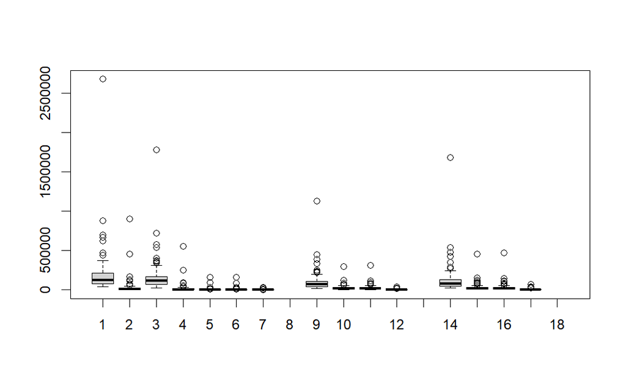

```r
# Create boxplots for each variable
boxplot(df$Total_population, df$IDPs, df$Non_displaced, df$IDPs_children, df$IDPs_men, df$IDPs_women, df$IDPs_elderly, df$Subtotal_IDPs, df$Non_disp_children, df$Non_disp_men, df$Non_disp_women, df$Non_disp_elderly, df$Subtotal_non_displaced, df$Total_children, df$Total_men, df$Total_women, df$Total_elderly, df$Total)
```

```r
# Identify potential outliers in each variable
outliers <- boxplot(df$Total_population, df$IDPs, df$Non_displaced, df$IDPs_children, df$IDPs_men, df$IDPs_women, df$IDPs_elderly, df$Subtotal_IDPs, df$Non_disp_children, df$Non_disp_men, df$Non_disp_women, df$Non_disp_elderly, df$Subtotal_non_displaced, df$Total_children, df$Total_men, df$Total_women, df$Total_elderly, df$Total, plot=FALSE)$out
# Print out the potential outliers
print(outliers)
```

```
  [1]  472223  620749 2683312  671363  440319  696454  884600   66200  454200   61500  904000   80100  132200   65300   60500  119800  166100
 [18]   64100  129700  406023 1779312  352571  539163  375019  576654  718500  363416  342300   38358  252758   37728  554567   53101   87001
 [35]   40860   40678   90113   90915   43927   87212   12219   90622   10809  158879   12503   18435   10358    8042    8941   13661   31194
 [52]    8357   16686   11307   84617   10911  160387   12628   19729   10263    8618   13267   30927   18234    4316   26204   30167    7034
 [69]    3819    2965   13064    3911    7569  251463 1128787  219248  336977  233948  392178  448694  239502  225586   71217  297744   63021
 [86]   87778   65633   82948  126343   69894  313705   91723   68833   76312  115716   39076   22684   16098   25216   27748   17204  289821
[103]  350220 1683354  423978  274808  482291  539609   83436  123642  456623   64988  106213   75991   96609  157537   81201  116693  474092
[120]   61961  111452   79096   89579  146643   30195   69243   29718   27975   40812
```

```r
# check summery stastistics on total population
summary(df$Total_population)
```

[output not shown]

```r
# check max population by region
max_population <- max(df$Total_population)
row_with_max_population <- df[df$Total_population == max_population,]
row_with_max_population
```

[output not shown]

```r
# view row with min population
min_population <- min(df$Total_population)
row_with_min_population <- df[df$Total_population == min_population,]
row_with_min_population
```

[output not shown]

is this boxplot, we can see there is outliers in our dataset that can effect our later analysis. in region columns there is an outlier banaadir who has much more population according to other regions. to solve this we can make a new state column, so states are around same population with banaadir state.

```r
# Create mapping between regions and states
mapping <- list(
  'Gedo' = 'Jubbaland',
  'Banadir' = 'Banaadir',
  'Mudug' = 'Galmudug',
  'Bay' = 'South West',
  'Lower Shabelle' = 'South West',
  'Bari' = 'Puntland',
  'Hiraan' = 'Hirshabeelle',
  'Nugaal' = 'Puntland',
  'Lower Juba' = 'Jubbaland',
  'Galgaduud' = 'Galmudug',
  'Sanaag' = 'Somaliland',
  'Awdal' = 'Somaliland',
  'Woqooyi Galbeed' = 'Somaliland',
  'Togdheer' = 'Somaliland',
  'Bakool' = 'South West',
  'Sool' = 'Puntland',
  'Middle Shabelle' = 'Hirshabeelle',
  'Middle Juba' = 'Jubbaland'
)


# Add new state column to data frame based on mapping variable we created
df$State <- sapply(df$Region, function(x) {
  ifelse(x %in% names(mapping), mapping[[x]], 'Unknown')
})
```

```r
# view States column unique values
unique(df$State)
```

```
[1] "Hirshabeelle" "South West"   "Jubbaland"    "Somaliland"   "Banaadir"     "Puntland"     "Galmudug"
```

```r
# verify and view dataframe with the new added column
df
```

now, after adding state column to our dataset, we can check the previous outlier solved or not?

```r
# check now the outlier is solved
outlier_df <- df %>%
  group_by(State) %>%
  summarize(Total_population = sum(Total_population))

# view outlier dataframe
cat("Mean   = ", mean(outlier_df$Total_population), "\n")
```

```
Mean   =  2248454
```

```r
cat("Median = ", median(outlier_df$Total_population), "\n")
```

```
Median =  2080632
```

```r
cat("Max    = ", max(outlier_df$Total_population), "\n")
```

```
Max    =  2863593
```

```r
cat("Min    = ", min(outlier_df$Total_population), "\n")
```

```
Min    =  1284519
```

```r
# Rearrange State column in the first position of the dataframe
df <- df[,c(ncol(df),1:(ncol(df)-1))]

# view and verify
df
```

| State | Region | District | Total_population | IDPs | Non_displaced | IDPs_children | IDPs_men | IDPs_women | IDPs_elderly | Non_disp_children | Non_disp_men | Non_disp_women | Non_disp_elderly | Total_children | Total_men | Total_women | Total_elderly |
| --- | --- | --- | --- | --- | --- | --- | --- | --- | --- | --- | --- | --- | --- | --- | --- | --- | --- |
| Hirshabeelle | Middle Shabelle | Adan Yabaal | 85950 | 0 | 85950 | 0 | 0 | 0 | 0 | 53232 | 15076 | 14796 | 2847 | 53232 | 15076 | 14796 | 2847 |
| South West | Lower Shabelle | Afgooye | 472223 | 66200 | 406023 | 38358 | 12219 | 11307 | 4316 | 251463 | 71217 | 69894 | 13450 | 289821 | 83436 | 81201 | 17766 |
| Jubbaland | Lower Juba | Afmadow | 233519 | 2600 | 230919 | 1507 | 480 | 444 | 170 | 143016 | 40503 | 39751 | 7649 | 144523 | 40983 | 40195 | 7819 |
| Jubbaland | Gedo | Baardheere | 172267 | 18400 | 153867 | 10662 | 3396 | 3143 | 1200 | 95295 | 26988 | 26487 | 5097 | 105957 | 30384 | 29630 | 6297 |
| Jubbaland | Lower Juba | Badhaadhe | 71363 | 2000 | 69363 | 1113 | 399 | 373 | 115 | 40590 | 13752 | 13359 | 1662 | 41703 | 14151 | 13732 | 1777 |
| South West | Bay | Baidoa | 620749 | 454200 | 166549 | 252758 | 90622 | 84617 | 26204 | 97462 | 33020 | 32076 | 3991 | 350220 | 123642 | 116693 | 30195 |
| Somaliland | Awdal | Baki | 55939 | 2700 | 53239 | 1503 | 539 | 503 | 156 | 31155 | 10555 | 10253 | 1276 | 32658 | 11094 | 10756 | 1432 |
| Hirshabeelle | Middle Shabelle | Balcad | 334620 | 61500 | 273120 | 37728 | 10809 | 10911 | 2052 | 173266 | 45703 | 48153 | 5998 | 210994 | 56512 | 59064 | 8050 |
| Banaadir | Banadir | Banadir | 2683312 | 904000 | 1779312 | 554567 | 158879 | 160387 | 30167 | 1128787 | 297744 | 313705 | 39076 | 1683354 | 456623 | 474092 | 69243 |
| Puntland | Bari | Bandarbayla | 42436 | 2000 | 40436 | 1227 | 352 | 355 | 67 | 25652 | 6766 | 7129 | 888 | 26879 | 7118 | 7484 | 955 |

[output cut: 64 more lines]

```r
NA
```

```r
# Install 'psych' package
install.packages('psych')
```

```r
# Load 'psych' package
library(psych)

# Generate descriptive statistics for data frame
describe(df)
```

[output not shown]

## Data Visualization

### our hypothesis in this analyze

1.What is the total population distribution in Somalia?  
2. How does the IDP population compare to the non-displaced population in Somalia?  
3. What is the total population by state?  
4. What is the total population by region?  
5. What is the total population by district?  
6. What is the IDP and non-displaced population like in states?  
7. What is the distribution of non-displaced population like?  
8. What is the distribution of IDPs like in states?  
9. How is the population mapped in states?

```r
# Install 'ggtext' package provides additional functionality for the ‘ggplot2’ package to allow for rich text formatting in plots.
install.packages('ggtext')
```

```r
# Install 'extrafont' package provides a way to use fonts other than the standard fonts in R graphics.
install.packages('extrafont')
```

### 1.What is the total population distribution in Somalia?

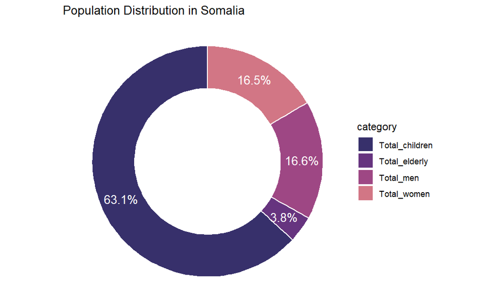

```r
library(ggplot2) # load ggplot2 package
library(extrafont) # load extrafont package
# Aggregate the data by calculating the sum of each population category
pop_sum <- colSums(df[, c("Total_children", "Total_men", "Total_women", "Total_elderly")])

# Calculate the percentage of each category
pop_pct <- pop_sum / sum(pop_sum) * 100

# Create a dataframe with the population sums, categories, and percentages
pop_df <- data.frame(population = pop_sum, category = names(pop_sum), percent = pop_pct)

# Define a color palette for the pie chart
my_colors <- c("#37306B", "#66347F", "#9E4784", "#D27685")

# Create a pie chart using ggplot2
ggplot(pop_df, aes(x="", y=population, fill=category)) +
  geom_bar(stat="identity", width=1, color = "white") +
  geom_text(aes(label = paste0(round(percent,1),"%")), position = position_stack(vjust = 0.5), color = "white", size = 4.5) +
  coord_polar("y", start=0) +
  scale_fill_manual(values = my_colors) +
  labs(title = "Population Distribution in Somalia") +
  theme_void() +
  theme(legend.position="right") +
  # Add 3D effect
  annotate("rect", xmin=-1.2, xmax=-1, ymin=-0.6, ymax=0.6, alpha=0.5, fill="white", color="white") +
  annotate("rect", xmin=1, xmax=1.2, ymin=-0.6, ymax=0.6, alpha=0.5, fill="white", color="white") +
  annotate("rect", xmin=-1.2, xmax=1.2, ymin=-0.6, ymax=-0.4, alpha=0.5, fill="white", color="white") +
  annotate("rect", xmin=-1.2, xmax=1.2, ymin=0.4, ymax=0.6, alpha=0.5, fill="white", color="white")
```

```r
NA
NA
NA
NA
```

the above bie chart shows population distribution, children are 63 percent of the population while men and women are almost identically same with 16.5 percent.

### 2. How does the IDP population compare to the non-displaced population in Somalia?

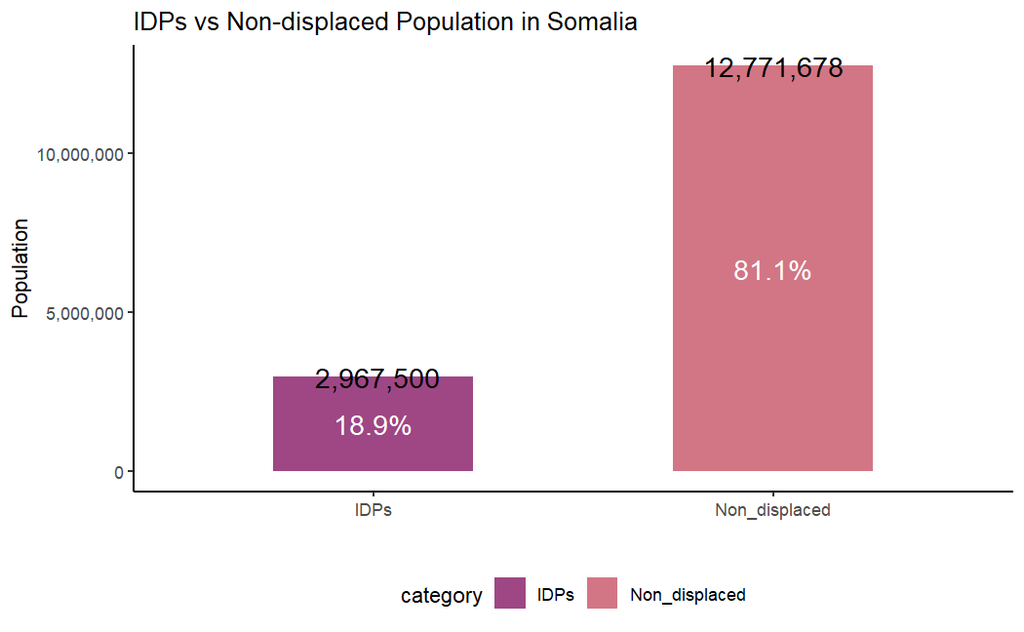

```r
# Load required packages
library(dplyr)     # Data manipulation
library(ggplot2)   # Graphics
library(reshape2)  # Data reshaping
library(scales)    # Plot scales
# Aggregate the data by calculating the sum of each population category
pop_sum <- colSums(df[, c("IDPs", "Non_displaced")])

# Calculate the percentage of each category
pop_pct <- pop_sum / sum(pop_sum) * 100

# Create a dataframe with the population sums, categories, and percentages
pop_df <- data.frame(population = pop_sum, category = names(pop_sum), percent = pop_pct)

# Define a color palette for the bar chart
my_colors <- c("#9E4784", "#D27685")

# Create a bar chart using ggplot2
ggplot(pop_df, aes(x=category, y=population, fill=category)) +
  geom_bar(stat="identity", width=0.5) +
  geom_text(aes(label = paste0(round(percent,1),"%")), position = position_stack(vjust = 0.5), color = "white", size = 5) +
  geom_text(aes(label = format(population, big.mark = ",")), position = position_stack(vjust = 1.0), color = "black", size = 5) +
  labs(title = "IDPs vs Non-displaced Population in Somalia", x="", y="Population") +
  scale_fill_manual(values = my_colors) +
  theme_classic() +
  theme(legend.position="bottom") +
  scale_y_continuous(labels = comma)
```

```r
NA
NA
```

the above bar chart shows IDPs and non displaced population side by side. over 81 percent are non displaced population and 18 percent are IDPs.

### 3. What is the total population by state?

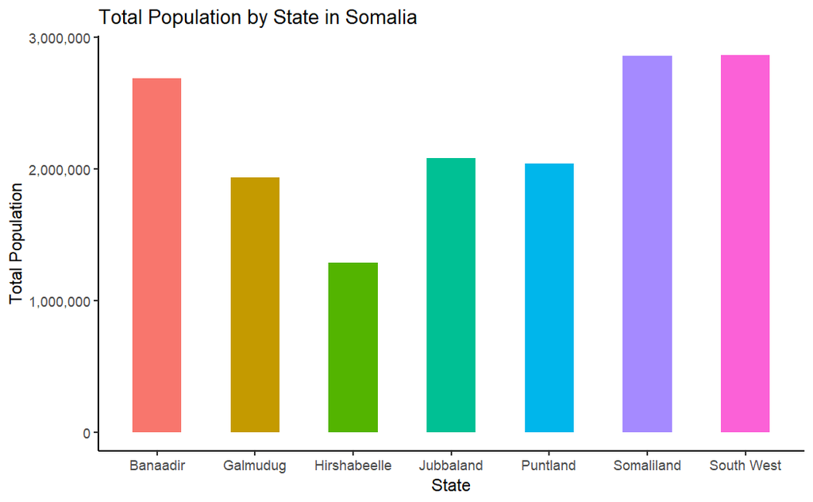

```r
# Create a bar chart using ggplot2
ggplot(df, aes(x= State, y=Total_population, fill=State)) +
  geom_bar(stat="identity", width=0.5) +
  labs(title = "Total Population by State in Somalia", x="State", y="Total Population") +
  theme_classic() +
  theme(legend.position="none") +
  scale_y_continuous(labels = comma)
```

in this bar chart, shows states with total population. somaliland and southwest are leading with similar numbers, followed by banaadir and others.

### 4. What is the total population by region?

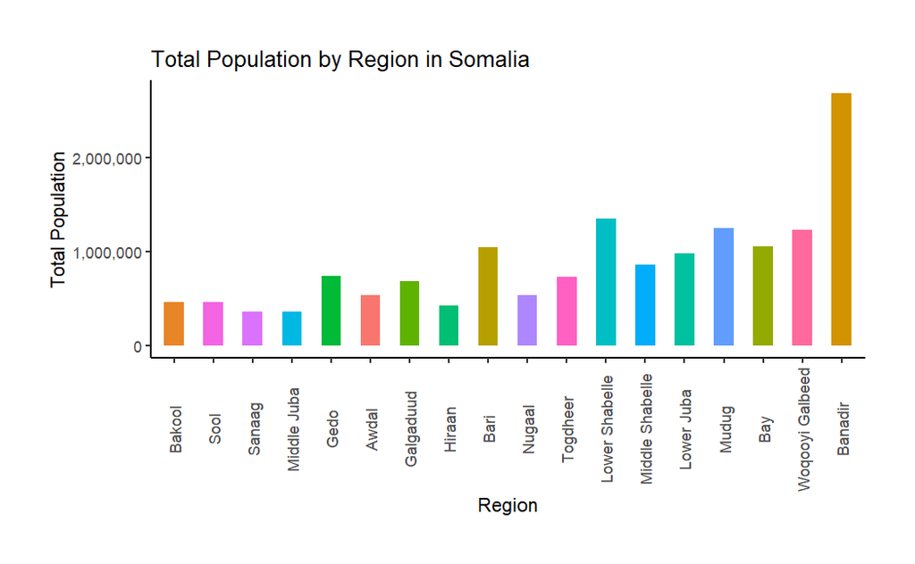

```r
# create ggplot bar chart
ggplot(df, aes(x= reorder(Region, +Total_population), y=Total_population, fill=Region)) +
  geom_bar(stat="identity", width=0.5) +
  #coord_flip() +
  labs(title = "Total Population by Region in Somalia", x="Region", y="Total Population") +
  theme_classic() +
  theme(legend.position="none", axis.text.x = element_text(angle = 90, vjust = 0.5), plot.margin = unit(c(1,1,1,1), "cm")) +
  scale_y_continuous(labels = comma)
```

in the above chart, you can see clearly banaadir is the outlier of this view. we solved with state column as shown previous above graph.

### 5. What is the total population by district?

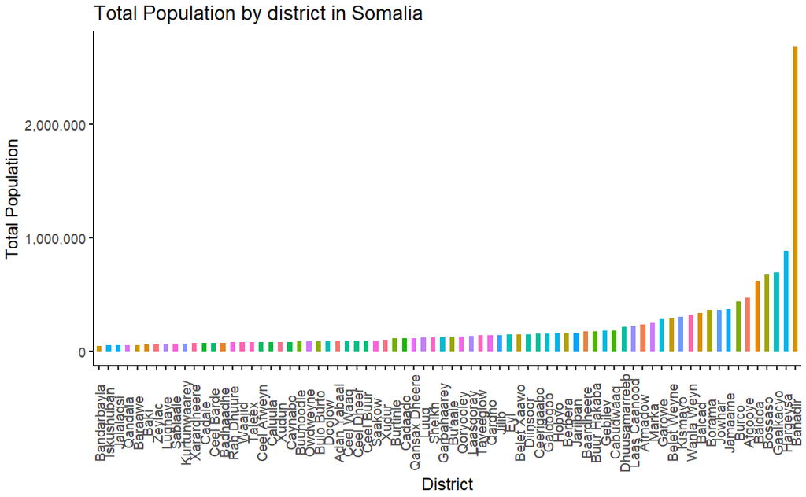

```r
# create ggplot bar chart
ggplot(df, aes(x= reorder(District, +Total_population), y=Total_population, fill=District)) +
  geom_bar(stat="identity", width=0.5) +
  #coord_flip() +
  labs(title = "Total Population by district in Somalia", x="District", y="Total Population") +
  theme_classic() +
  theme(legend.position="none", axis.text.x = element_text(angle = 90, vjust = 0.5), plot.margin = unit(c(0.1,0.1,0.1,0.1), "cm")) +
  scale_y_continuous(labels = comma)
```

in this chart, shows districts and population with banaadir outlier. since banaadir is not listed its districts it is clear that has much population according to other small districts in the country.

### 6. What is the IDP and non-displaced population like in states?

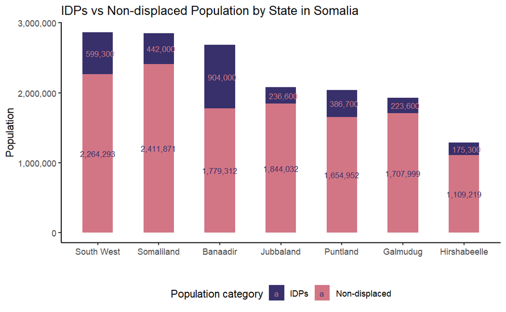

```r
# Load required packages
library(dplyr)     # Data manipulation
library(ggplot2)   # Graphics
library(reshape2)  # Data reshaping
library(scales)    # Plot scales

# Aggregate the data by state and population category
pop_agg <- df %>% group_by(State) %>% summarise(IDPs = sum(IDPs), Non_displaced = sum(Non_displaced), Total_population = sum(Total_population))

# Manually reorder the states by total population
pop_agg$State <- factor(pop_agg$State, levels = pop_agg$State[order(pop_agg$Total_population, decreasing = TRUE)])

# Select only IDPs and Non_displaced columns
pop_melt <- pop_agg %>% select(State, IDPs, Non_displaced) %>% melt(id.vars = "State")

# Define a color palette for the stacked bar chart
my_colors <- c("#37306B", "#D27685", "#66347F", "#9E4784")

# Create a stacked bar chart using ggplot2
ggplot(pop_melt, aes(x=State, y=value, fill=variable)) +
  geom_bar(stat="identity", width=0.5) +
  geom_text(aes(label = format(value, big.mark = ","), color = variable),
            position = position_stack(vjust = 0.5), size = 3) +
  labs(title = "IDPs vs Non-displaced Population by State in Somalia", x="", y="Population") +
  scale_fill_manual(values = my_colors, name="Population category", labels=c("IDPs", "Non-displaced")) +
  scale_color_manual(values = c("#D27685", "#37306B"), name="Population category", labels=c("IDPs", "Non-displaced")) +
  theme_classic() +
  theme(legend.position="bottom") +
  scale_y_continuous(labels = comma)
```

```r
NA
NA
```

in the above chart, it shows IDPs and non displaced population for every state. the most IDPs live in banaadir. the most non displaced people live in somaliland.

### 7. What is the distribution of non-displaced population like?

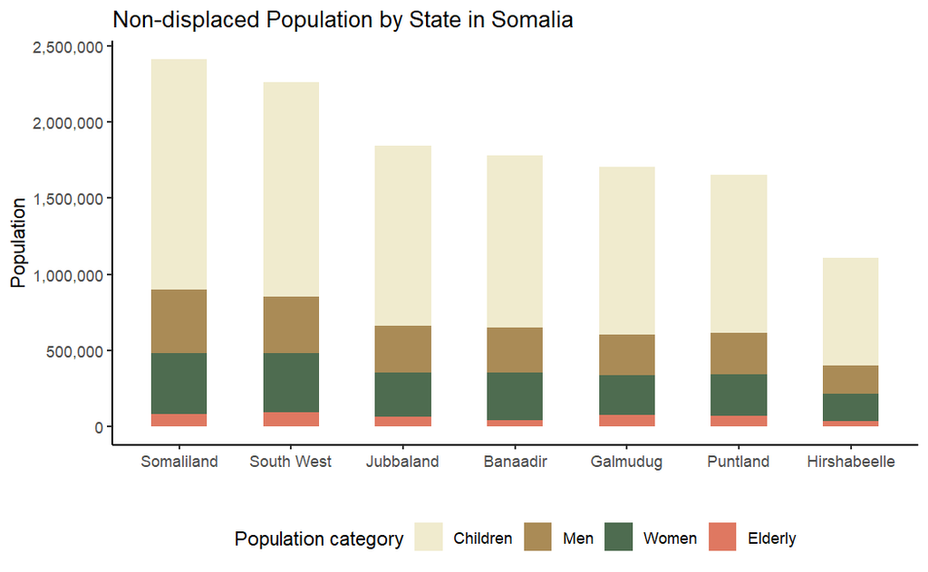

```r
# Load necessary packages
library(dplyr)    # For working with data frames
library(ggplot2)  # For creating graphics
library(reshape2) # For transforming data

# Aggregate the data by state and population category
pop_agg <- df %>% group_by(State) %>%
  summarise(Non_disp_children = sum(Non_disp_children),
            Non_disp_men = sum(Non_disp_men),
            Non_disp_women = sum(Non_disp_women),
            Non_disp_elderly = sum(Non_disp_elderly))

# Melt the data to long format
pop_melt <- pop_agg %>% select(State, Non_disp_children, Non_disp_men, Non_disp_women, Non_disp_elderly) %>%
  melt(id.vars = "State")

# Define a color palette for the stacked bar chart
my_colors <- c("#F0EBCE", "#AA8B56", "#4E6C50", "#DF7861")

# Manually reorder the states by total Non-displaced population
pop_melt$State <- reorder(pop_melt$State, -pop_melt$value)

# Create a stacked bar chart using ggplot2
ggplot(pop_melt, aes(x = State, y = value, fill = variable)) +
  geom_bar(stat = "identity", width = 0.5) +
  labs(title = "Non-displaced Population by State in Somalia", x = "", y = "Population") +
  scale_fill_manual(values = my_colors, name = "Population category",
                    labels = c("Children", "Men", "Women", "Elderly")) +
  theme_classic() +
  theme(legend.position = "bottom") +
  scale_y_continuous(labels = comma)
```

```r
NA
NA
NA
```

In the above chart, shows non displaced population distribution in states. most children and most men live in somaliland while most elderly live in south west.

### 8. What is the distribution of IDPs like in states?

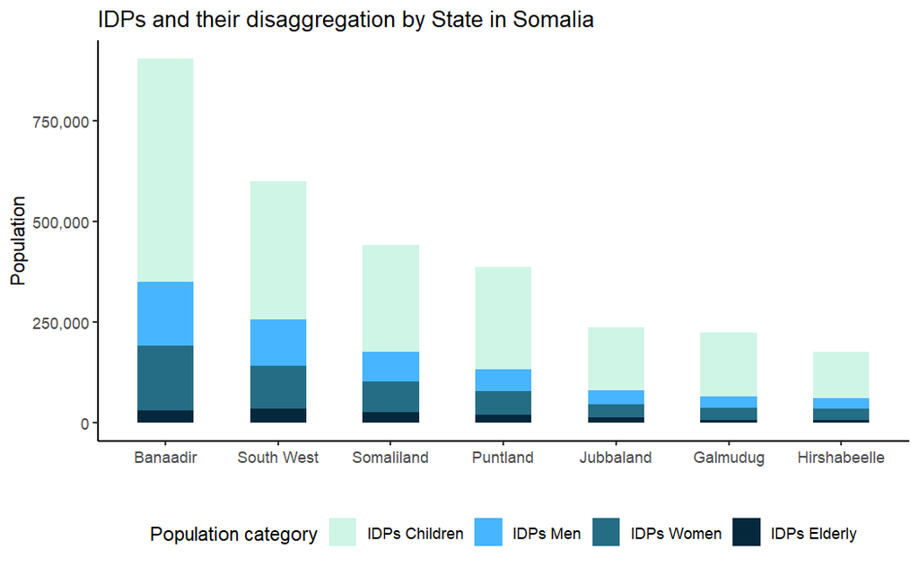

```r
# Load necessary packages
library(dplyr)    # For working with data frames
library(ggplot2)  # For creating graphics
library(reshape2) # For transforming data

# Aggregate the data by state and population category
pop_agg <- df %>% group_by(State) %>%
  summarise(IDPs_children = sum(IDPs_children),
            IDPs_men = sum(IDPs_men),
            IDPs_women = sum(IDPs_women),
            IDPs_elderly = sum(IDPs_elderly),
            Total_IDPs = sum(IDPs_children + IDPs_men + IDPs_women + IDPs_elderly))

# Reorder the states by total IDPs population
pop_agg$State <- reorder(pop_agg$State, pop_agg$Total_IDPs, FUN = function(x) -x)

# Melt the data to long format
pop_melt <- pop_agg %>% select(State, starts_with("IDPs_")) %>%
  melt(id.vars = "State", variable.name = "Population_category", value.name = "Population")

# Define a color palette for the stacked bar chart
my_colors <- c("#CFF5E7", "#47B5FF", "#256D85", "#06283D")

# Create a stacked bar chart using ggplot2
ggplot(pop_melt, aes(x=State, y=Population, fill=Population_category)) +
  geom_bar(stat="identity", width=0.5) +
  labs(title = "IDPs and their disaggregation by State in Somalia", x="", y="Population") +
  scale_fill_manual(values = my_colors, name="Population category",
                    labels=c("IDPs Children", "IDPs Men", "IDPs Women", "IDPs Elderly")) +
  theme_classic() +
  theme(legend.position="bottom") +
  scale_y_continuous(labels = comma)
```

```r
# Install necessary packages
install.packages('maps')    # For creating maps
install.packages('mapdata') # For providing map data
install.packages('sf')      # For working with spatial data
```

```r
install.packages('mapproj') # a package For map projections
```

[output not shown]

```r
# Load necessary packages
library(tidyverse) # For data manipulation and visualization
library(magrittr)  # For piping functions
library(ggplot2)   # For creating graphics
library(maps)      # For creating maps
library(mapproj)   # For map projections
```

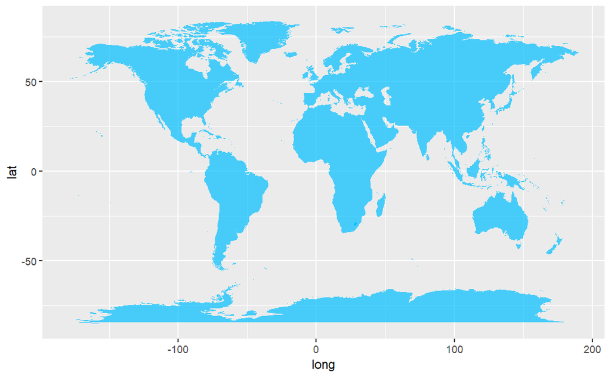

```r
# Let’s take a look at the world map provided within the maps library.
World <- map_data("world")
ggplot() +
  geom_polygon(data = World, aes(x=long, y = lat, group = group), fill="deepskyblue", alpha=0.7)
```

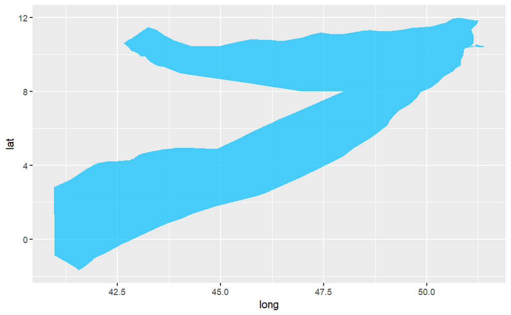

```r
# We will filter the library for the one country to use in our case Somalia.
Somalia <- map_data("world") %>% filter(region=="Somalia")
  ggplot() +
  geom_polygon(data = Somalia, aes(x=long, y = lat, group = group), fill="deepskyblue", alpha=0.7)
```

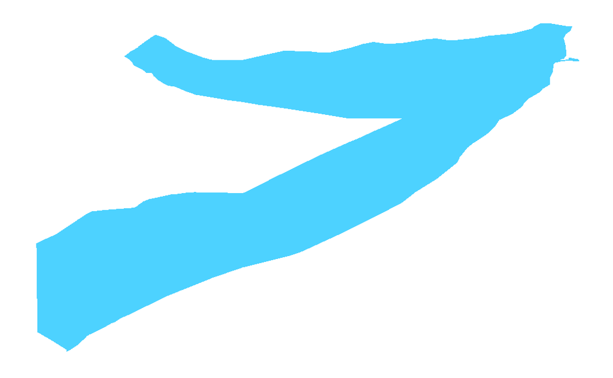

```r
# It’s time to improve some visuals before we can actually start plotting. I am going to make the map as clean as possible — we do not need the coordinates or the grey background for our purpose.
ggplot() +
  geom_polygon(data = Somalia, aes(x=long, y = lat, group = group), fill="deepskyblue", alpha=0.7) +
   theme_minimal() +
  theme(legend.position = 'none', panel.grid.major = element_blank(), panel.grid.minor = element_blank(), axis.text = element_blank(), axis.title = element_blank())
```

```r
# we will fetch State and Total_population columns in our original dataset to apply map graphics
# Group by sum using dplyr
# returns tibble table
df_grouped <- df %>% group_by(State) %>%
  summarise(Population=sum(Total_population),
            .groups = 'drop')
```

```r
# view sliced dataframe
df_grouped
```

| State | Population |
| --- | --- |
| Banaadir | 2683312 |
| Galmudug | 1931599 |
| Hirshabeelle | 1284519 |
| Jubbaland | 2080632 |
| Puntland | 2041652 |
| Somaliland | 2853871 |
| South West | 2863593 |

```r
NA
```

```r
# delete dataframe1, dataframe2
#rm("df2", "df_lat_long", "lat_long")

# display
#ls()
```

```r
# Convert tibble to df and rename to remember well what dataframe is about
df_lat_long <- df_grouped %>% as.data.frame()
df_lat_long
```

| State | Population |
| --- | --- |
| Banaadir | 2683312 |
| Galmudug | 1931599 |
| Hirshabeelle | 1284519 |
| Jubbaland | 2080632 |
| Puntland | 2041652 |
| Somaliland | 2853871 |
| South West | 2863593 |

```r
NA
```

```r
# Load necessary packages
library(tibble) # For working with data frames

# create lat and long vectors to add our dataframe
df2 <- tibble(
  lat = c(2.1187, 6.0404, 4.7360, 1.257377, 9.7866, 9.4117, 2.609846),
  long = c(45.3369, 47.7638, 45.2040, 42.008912, 49.3653, 46.8253, 43.630437)
)

# Convert tibble to df
df2 <- df2 %>% as.data.frame()
df2
```

| lat | long |
| --- | --- |
| 2.118700 | 45.33690 |
| 6.040400 | 47.76380 |
| 4.736000 | 45.20400 |
| 1.257377 | 42.00891 |
| 9.786600 | 49.36530 |
| 9.411700 | 46.82530 |
| 2.609846 | 43.63044 |

```r
NA
```

```r
# add two dataframes together
df_lat_long <- cbind(df_lat_long, df2)
df_lat_long
```

| State | Population | lat | long |
| --- | --- | --- | --- |
| Banaadir | 2683312 | 2.118700 | 45.33690 |
| Galmudug | 1931599 | 6.040400 | 47.76380 |
| Hirshabeelle | 1284519 | 4.736000 | 45.20400 |
| Jubbaland | 2080632 | 1.257377 | 42.00891 |
| Puntland | 2041652 | 9.786600 | 49.36530 |
| Somaliland | 2853871 | 9.411700 | 46.82530 |
| South West | 2863593 | 2.609846 | 43.63044 |

```r
NA
```

### 9. How is the population mapped in states?

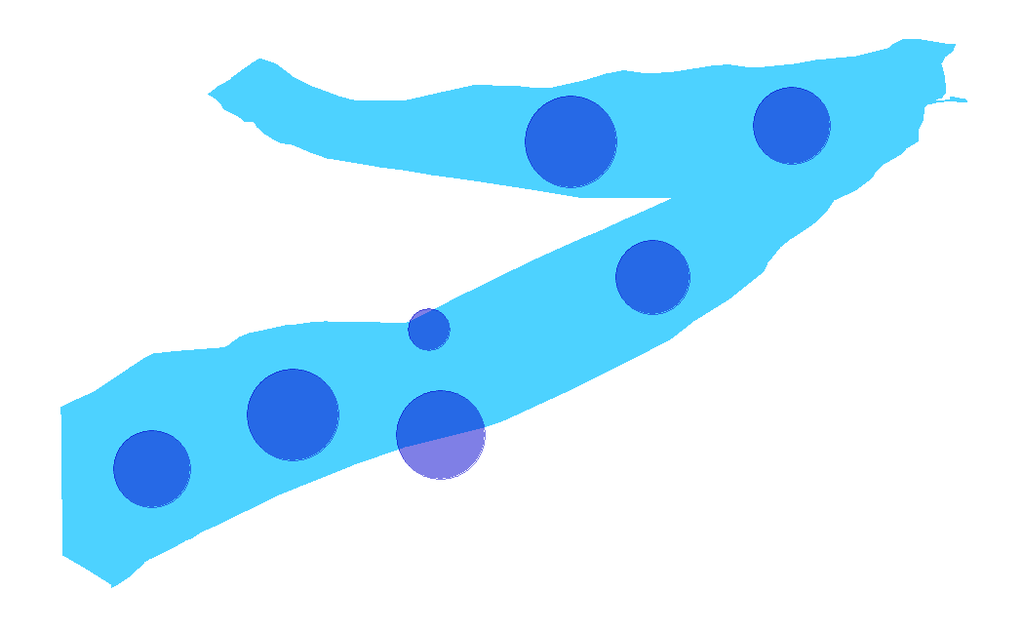

```r
# Time to add our cities to the clean map using their coordinates and geom_point() function
ggplot() +
  geom_polygon(data = Somalia, aes(x=long, y = lat, group = group), fill="deepskyblue", alpha=0.7) +
    geom_point( data=df_lat_long, aes(x=long, y=lat, size=Population,),  color="mediumblue",  alpha=0.5) +
    scale_size_continuous(range=c(10, 22)) +
   theme_minimal() +
   theme(legend.position = 'none', panel.grid.major = element_blank(), panel.grid.minor = element_blank(), axis.text = element_blank(), axis.title = element_blank())
```

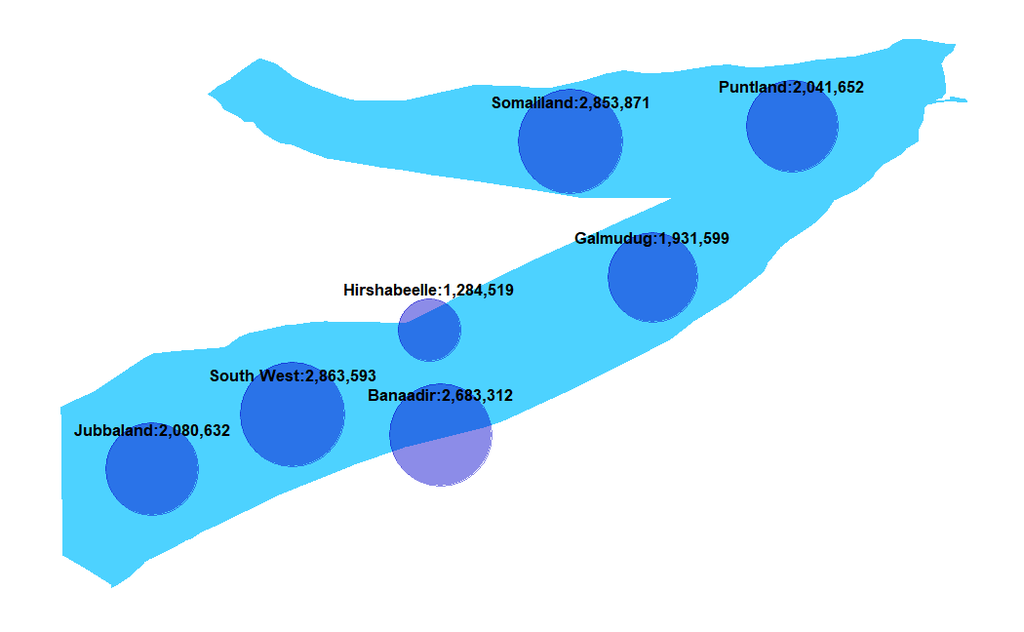

```r
# next step will be adding labels. I want each label to include the name of the city and the population with a comma separator.
ggplot() +
  geom_polygon(data =Somalia, aes(x=long, y = lat, group = group), fill="deepskyblue", alpha=0.7) +
    geom_point( data=df_lat_long, aes(x=long, y=lat, size=Population,),  color="mediumblue",  alpha=0.45) +
    scale_size_continuous(range=c(15, 25)) +
     geom_text(data = df_lat_long, label=paste0(df_lat_long$State, ":", as.character(format(df_lat_long$Population, big.mark=","))), aes(x=long, y=lat), hjust=0.5, vjust=-2.7, fontface='bold', size=3) +
   theme_minimal() +
   theme(legend.position = 'none', panel.grid.major = element_blank(), panel.grid.minor = element_blank(), axis.text = element_blank(), axis.title = element_blank())
```

the above graph shows, where states are located in the country and total population live in. we can say that southern erea population are more than the northen population.